Peter Nagy - 100672801

CSCI 2000U - Final Project

# Chicago crimes 2001-2018

Crimes that occurred in the City of Chicago from 2001, up until mid Nov. 2018

## Description

> This dataset reflects reported incidents of crime (with the exception of murders where data exists for each victim) that occurred in the City of Chicago from 2001 up until approximately half of November 2018.

> Source: [Chicago Data Portal](https://data.cityofchicago.org/Public-Safety/Crimes-2001-to-present/ijzp-q8t2)

## Analysis

### Imports

```python
import numpy as np
import pandas as pd
import matplotlib.pyplot as mp
from IPython.display import Markdown
%matplotlib inline
```

### Importing data with specific columns of interest

Using "read_csv" method from the pandas library and using parameter "usecols" to truncate the data to only the 10 important columns

```python
data = pd.read_csv("city_of_chicago_crimes_2001_to_present.csv", usecols=["Case Number", "Date", "Block",
                                                                          "Primary Type", "Description",
                                                                          "Location Description", "Arrest",
                                                                          "Domestic", "District", "Community Area"])
```

### Data preview

```python
data.head()
```

|  | Case Number | Date | Block | Primary Type | Description | Location Description | Arrest | Domestic | District | Community Area |
| --- | --- | --- | --- | --- | --- | --- | --- | --- | --- | --- |
| 0 | HY189866 | 03/18/2015 07:44:00 PM | 047XX W OHIO ST | BATTERY | AGGRAVATED: HANDGUN | STREET | False | False | 11.0 | 25.0 |
| 1 | HY190059 | 03/18/2015 11:00:00 PM | 066XX S MARSHFIELD AVE | OTHER OFFENSE | PAROLE VIOLATION | STREET | True | False | 7.0 | 67.0 |
| 2 | HY190052 | 03/18/2015 10:45:00 PM | 044XX S LAKE PARK AVE | BATTERY | DOMESTIC BATTERY SIMPLE | APARTMENT | False | True | 2.0 | 39.0 |
| 3 | HY190054 | 03/18/2015 10:30:00 PM | 051XX S MICHIGAN AVE | BATTERY | SIMPLE | APARTMENT | False | False | 2.0 | 40.0 |
| 4 | HY189976 | 03/18/2015 09:00:00 PM | 047XX W ADAMS ST | ROBBERY | ARMED: HANDGUN | SIDEWALK | False | False | 11.0 | 25.0 |

### Data volume

#### Printing number of rows and columns of dataset

Using "shape" method from the data to view the dataset size (rows, columns)

```python
data.shape
```

```
(6747040, 10)
```

The dataset contains **6,747,040 rows** and **10 columns**

### Data quality

The data source presents multiple crimes that occured in Chicago between 2001 and 2018. The crimes are described and located by the block, by a general location (street, apartment, sidewalk, ...), by the Chicago district number and by the Chicago community area number. Every crime is labeled by a case number, which makes it easy to look up for further information. Finally, every crime mentions if the suspect was arrested and if it was a domestic crime.

It's relevant to data science, since we, as data scientists, can calculate and come up with a lot of conclusions concerning crime in Chicago or crime in general as well. For example, which areas in Chicago are the safest and which ones are the riskiest, what location (street, sidewalk, ...) should people avoid to remain safe and many more.

### Experiment

First let's insert the data into a dataframe in order to process it easier

Using "DataFrame" method from the pandas library to transform the data to a dataframe

```python
dataF = pd.DataFrame(data)
```

#### Community area crime analysis

Using "groupby" method from the dataframe will group all of the same community areas, then taking the column "Community Area" and counting how many elements are in each group using "count" method

```python
comAreaCount = dataF.groupby(["Community Area"])["Community Area"].count()
```

Now let's calculate the community area which has the most crime in it

Using "idxmax" method from the community area counts returns the index of the maximum, in other words the most common community area number from our dataset

```python
comAreaCount.idxmax()
```

```
25.0
```

The community area **#25** refers to **Austin, Illinois**

And the number of crimes committed there in the past 18 years

Using "max" method from the community area counts returns the number of crime committed in the most community area

```python
comAreaCount.max()
```

```
390763
```

Now let's plot this community area crime rate

Using "plot" and "bar" method from the community area counts returns a data visualization of the community areas and their crime rate. Also using "figsize" argument and setting the length to 20 and the height to 5 to enlarge our plot in order to properly display all the community areas.

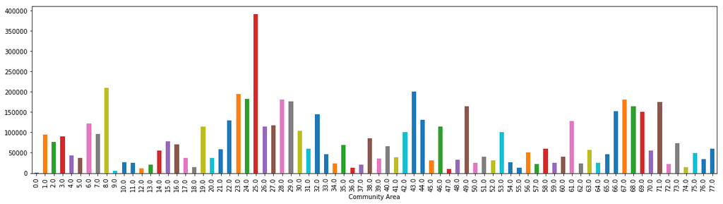

```python
comAreaCount.plot.bar(figsize=(20,5));
```

This graph tells us that there is quite a large difference between the worst community area and the rest.

Which is a hint that community area #25 is an extreme outlier.

Let's see what the data looks if sorted

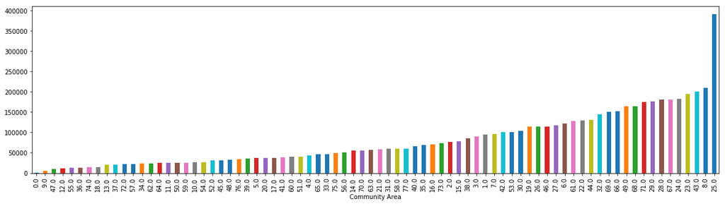

```python
comAreaCount.sort_values().plot.bar(figsize=(20,5));
```

##### Conclusion

Now we can observe that there is a lot of good community areas, where crime is less present, but there is only one community area where crime rate is that atrocious and that's **Austin, Illinois**.

#### Crime location description analysis

Using "groupby" method again, this time with the "Location Description" will group the same crime locations

```python
crimLocCount = dataF.groupby(["Location Description"])["Location Description"].count()
```

The most common crime location

```python
crimLocCount.idxmax()
```

```
'STREET'
```

With a total amount of crime there

```python
crimLocCount.max()
```

```
1770601
```

Plotting the top 10 crime locations

After sorting the count of crime location values with "sort_values" method, we plot the 10 last crime locations (10 highest elements) since the rest of the values are close to negligible compared to the top 10

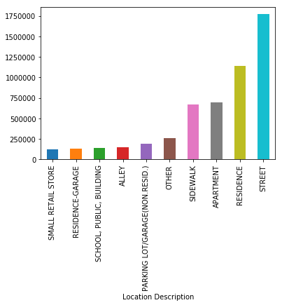

```python
crimLocCount.sort_values()[-10:].plot.bar();
```

Let's also calculate how much does the street, the residence, the apartment and the sidewalk crimes represent out of all crimes.

```python
crimLocCount.sort_values()[-4:].sum() / crimLocCount.sum()
```

```
0.6341086326684605
```

##### Conclusion

We conclude that **the street, the residence, the apartment and the sidewalk** is where most of the crimes happen, precisely **63.4%** out of all the crimes are committed at these 4 locations.

#### Crime types

Using "groupby" method again, this time with the "Primary Type" will group the same crimes types

```python
crimTypeCount = dataF.groupby(["Primary Type"])["Primary Type"].count()
```

The most common crime type

```python
crimTypeCount.idxmax()
```

```
'THEFT'
```

With a total amount of crime commited by the type

```python
crimTypeCount.max()
```

```
1417997
```

Plotting the crime types

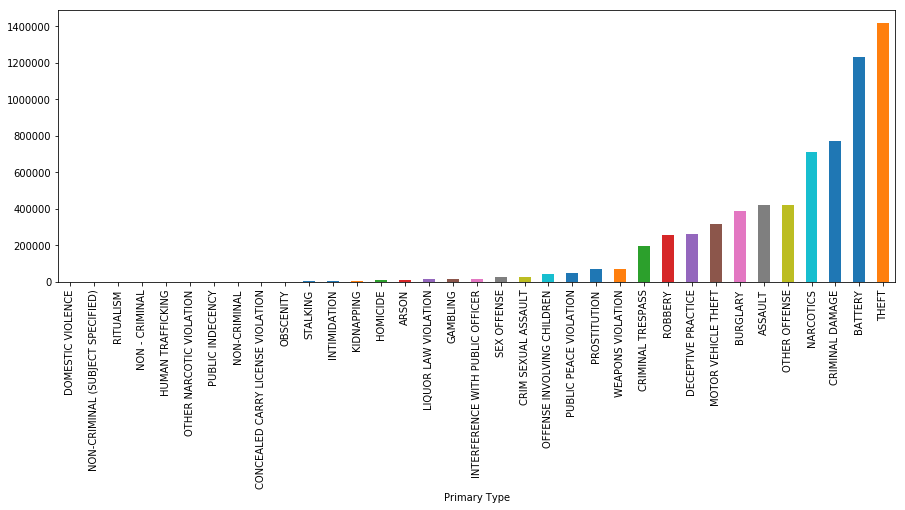

```python
crimTypeCount.sort_values().plot.bar(figsize=(15,5));
```

Calculating the proportion of the top 4 crime types over all crimes

```python
crimTypeCount.sort_values()[-4:].sum() / crimTypeCount.sum()
```

```
0.612504594607413
```

##### Conclusion

Theft, battery, criminal damage and narcotics are the most common crime types, precisely they form 61.3% of all the crime types

Now let's see what is the most common crime committed in each of the top 10 locations

#### Crime location vs Crime commited

Using "groupby" method again, this time with the "Location Description" and the "Primary Type" will group the same locations and crime types together and we also arrange the dataset by "Location Description" followed by their count

```python
crimLocTypeCount = dataF.groupby(["Location Description", "Primary Type"])["Location Description"].count()
```

First we create a new DataFrame and name it "crimLocType" composed of 2 columns ("Crime Location" and "Crime Type"). Then we set the index to be "Crime Location". For every location from the top 10 locations, get the highest crime type commited in that location and append it to the "crimLocType" dataset. Finally output the dataset created.

```python
crimLocType = pd.DataFrame(columns=["Crime Location", "Crime Type"])
crimLocType = crimLocType.set_index(["Crime Location"])
for i in crimLocCount.sort_values()[-10:].index:
    crimLocType.loc[i] = [crimLocTypeCount[i].idxmax()]

crimLocType
```

| Crime Location | Crime Type |
| --- | --- |
| SMALL RETAIL STORE | THEFT |
| RESIDENCE-GARAGE | BURGLARY |
| SCHOOL, PUBLIC, BUILDING | BATTERY |
| ALLEY | NARCOTICS |
| PARKING LOT/GARAGE(NON.RESID.) | THEFT |
| OTHER | THEFT |
| SIDEWALK | NARCOTICS |
| APARTMENT | BATTERY |
| RESIDENCE | BATTERY |
| STREET | THEFT |

And let's see what is top 10 most common combination of location and crime type

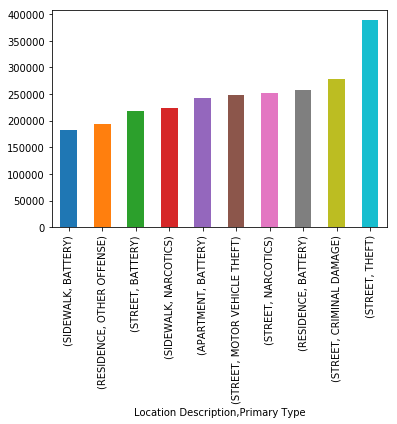

```python
crimLocTypeCount.sort_values()[-10:].plot.bar();
```

##### Conclusion

The highest risk locations involve **theft, battery, burglary and narcotics**

#### Arrest analysis

Let's analyze now the arrests proportions and then mix it with the crime type to find the correlation

```python
crimArrestCount = dataF.groupby(["Arrest"])["Arrest"].count()
```

```python
crimArrestCount
```

```
Arrest
False    4875610
True     1871430
Name: Arrest, dtype: int64
```

```python
crimArrestCount[True]/crimArrestCount.sum()
```

```
0.277370520998838
```

##### Conclusion

The overall proportion of successful arrests is about **27.7%**, which is really low

#### Arrest vs Crime type analysis

Let's calculate the crime types with the maximum proportion of successful arrests and the crime types with the minimum proportion of successful arrests

First let's create the combined dataframe

```python
crimArrestTypeCount = dataF.groupby(["Primary Type", "Arrest"])["Arrest"].count()
```

Next, let's create a dataframe named "crimArrestType" with the proportion of successful arrests of each crime type

```python
crimArrestType = pd.DataFrame(columns=["Crime type", "Crime Proportion of successful arrests"])
crimArrestType = crimArrestType.set_index(["Crime type"])
for i in crimTypeCount.index:
    crimArrestType.loc[i] = [crimArrestTypeCount[i][True]/crimArrestTypeCount[i].sum()]
```

Now let's visualize the dataset by sorting and plotting it

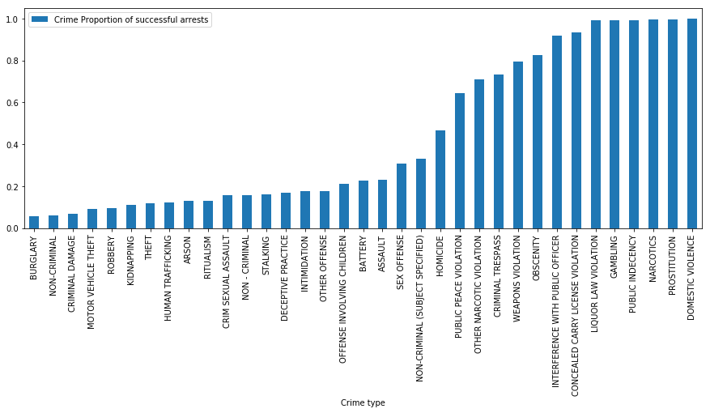

```python
crimArrestType.sort_values(by="Crime Proportion of successful arrests").plot.bar(figsize=(15,5));
```

Finally, let's get the maximum proportion of successful arrests crime types. In order to do that, since there is a couple, let's get the ones that have a proportion over 99%.

```python
maxCrimTypes = crimArrestType["Crime Proportion of successful arrests"] > 0.99
```

The following list contains the ones that have a proportion over 99%

```python
crimArrestType[maxCrimTypes]
```

| Crime type | Crime Proportion of successful arrests |
| --- | --- |
| DOMESTIC VIOLENCE | 1.000000 |
| GAMBLING | 0.992789 |
| LIQUOR LAW VIOLATION | 0.991111 |
| NARCOTICS | 0.994080 |
| PROSTITUTION | 0.996092 |
| PUBLIC INDECENCY | 0.993789 |

```python
minCrimTypes = crimArrestType["Crime Proportion of successful arrests"] < 0.1
```

```python
crimArrestType[minCrimTypes]
```

| Crime type | Crime Proportion of successful arrests |
| --- | --- |
| BURGLARY | 0.057259 |
| CRIMINAL DAMAGE | 0.070589 |
| MOTOR VEHICLE THEFT | 0.091272 |
| NON-CRIMINAL | 0.060976 |
| ROBBERY | 0.096989 |

##### Conclusion

Domestic violence, gambling, liquor law violation, narcotics, prostitution and public indecency are 6 crimes that are almost always caught with an arrest rate of over 99%.